# Crypto Portfolio VaR

Monika Monstvilaite

2018-03-19

# Analysis based on data available at 2018-03-22 01:00:00

# Marginal Log-Returns

The historical means of the data are the following:

```
##   BCH   BTC   ETH   LTC
## 0.003 0.003 0.002 0.004
```

```
##   BCH   BTC   ETH   LTC
## 0.100 0.060 0.062 0.085
```

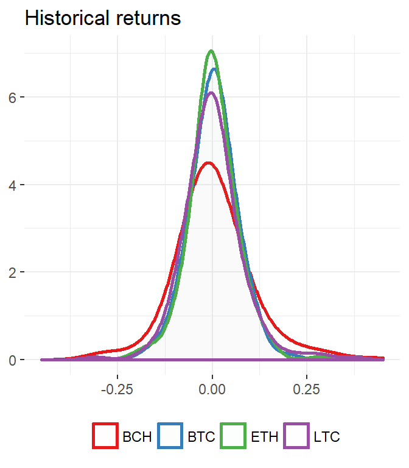

# ARMA-GARCH models fitted

## Standardized error distribution

# Transforming to uniform distribution

Nescessary in order to investigate dependence structure

# R-Vine copula

Instead of using correlation between variables, we will use r-vine copula. It is done so because correlation is not able to capture the nuances of assets that are correlated in for e.g. left tail of a distribution, but not a right tail. Intuition: cryptocurrencies might all crash at the same time, but when the market is doing well, they are uncorrelated.

Regular vine copula is a method to construct one solution for a simplified pair copula construction such that it would be as close as possible to real multivariate distribution that we aim to model. This way we are also able capture the dependency structure between the variables in an efficient way.

Kendalls $\tau$ is given by: $\tau = P((X_1-X_2)(Y_1-Y_2) >0)-P((X_1-X_2)(Y_1-Y_2) < 0)$

where $(X_1, Y_1) \sim F$ and $(X_2, Y_2) \sim F$ are independent pairs of random variables. Kendall’s $\tau$ is a rank correlation. It does not depend directly on the values and thus is invariant under strictly monotone transformations (cite(Gruber)). On the contrary, linear correlation parameter Pearson’s $\rho$ is it not invariant under non-linear strictly increasing transformations, meaning that value of Pearson’s $\rho$ depends on marginal distributions. That is why Kendall’s $\tau$ is a more reliable measure in our case.

We plot here the dependence structure. Tree graph below shows the strongest dependencies between cryptocurrencies based on Kendall’s $\tau$.

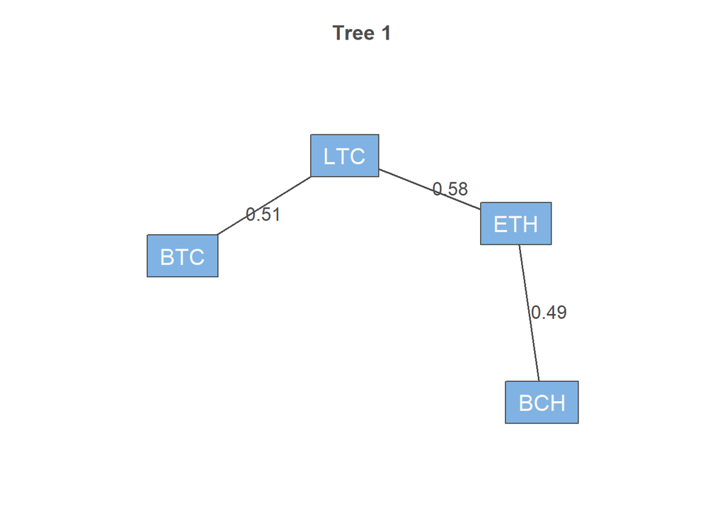

Please note below how variables are encoded:

| 1 | 2 | 3 | 4 |
| --- | --- | --- | --- |
| BCH | BTC | ETH | LTC |

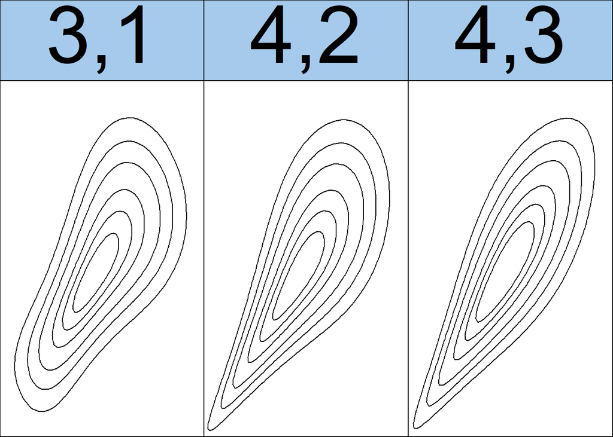

Copulas can help to perceive and visualize the nuances of dependence which is useful when describing the dependence of extreme events. In a figure above we can see that dependence structure can look very different and is not nescessarily symmetrical. Since copulas reveal dependence on a quantile scale, it is especially useful in the context of quantile based risk measures.

# Prediction one day ahead

## Backtransforming

Calculating variance from GARCH:

$\sigma_{t+1}^2 = \omega + \alpha_1 \epsilon_t^2 + \beta_1 \sigma_t^2$

$\epsilon_{t+1} = \sigma_{t+1} z$

# Prediction of return distribution one day ahead

$r_{t+1} = \mu + \epsilon_{t+1} + ar_1 r_t + ma_1 \epsilon_t$

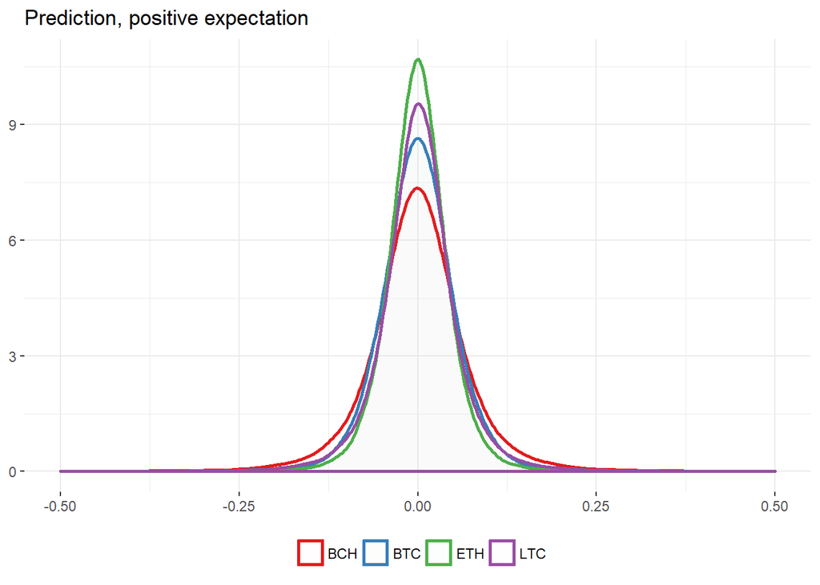

```
## variable    value
##       NA    4e-04
```

# Portfolio. FAT LEFT TAIL

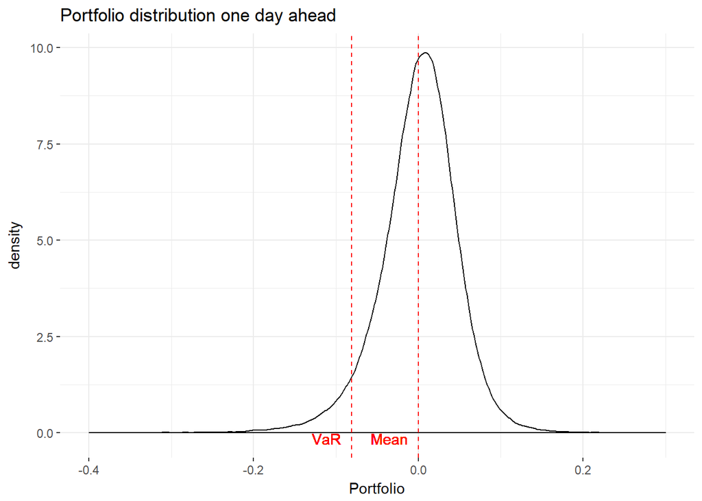

```
## [1] -0.08128372
```

```
## [1] 0.0036
```

If investing in all assets equally, expected return is:

```
##    Portfolio
## 0.0004443416
```